# Tipping points in diversified farming systems

Melissa Chapman

espm

Serge Wiltshire

espm

Timothy Bowles

espm

Liz Carlisle

ucsb

Fredrico Castillo

espm

David Gonthier

ky

Alastair Iles

espm

Daniel Karp

davis

Claire Kremen

espm, ucb

Jeff Liebert

cornell

Elissa Olimpi

davis

Matthew Ryan

cornell

Amber Sciligo

organic

Jennifer Thompson

espm

Hannah Waterhouse

espm

Kenzo Eszquivel

espm

Sasha Gennet

tnc

Carl Boettiger

espm

2021-02-15

Abstract

The emergence and impact of tipping points are of great interest in both social and ecological research. Despite widespread recognition of the importance of feedbacks between human and environmental systems, it is often assumed that the observed nonlinear dynamics in these coupled systems rest within either underlying human or environmental processes. Using adoption of agroecological practices as a case study, we show how bistability in ecosystem states and services can emerge purely from the temporal feedbacks between human decisions and ecological responses. We propose that the understanding the mechanisms of tipping points in social-environmental systems is critical to designing effective policy interventions in numerous environmental contexts. For example, our results indicate how policies which increase the duration of land tenure and provide long-term incentives are particularly effective at enhancing the practices that promote ecosystem services.

# Introduction

Both ecosystems and social systems can change states abruptly as the result of crossing critical thresholds. Theories of ecological multistability have long described this phenomenon (Beisner, Haydon, and Cuddington 2003; Scheffer et al. 2001) and explored how management impacts stability landscapes of these systems (Horan et al. 2011). Tipping points in natural systems are generally assumed to stem from complex ecological processes like population dynamics and species interactions (Dai et al. 2012; Mumby, Hastings, and Edwards 2007; Scheffer 2010). Similarly, examples of tipping points in social systems, ranging from the collapse of civilizations (Downey, Haas, and Shennan 2016) to the spread of innovations through social network processes (Redmond 2003) suggest that observed nonlinearities in social systems can result from features of human decisions.

Agriculture is a fundamental driver of anthropogenic ecological change (Foley et al. 2005, 2011; Stoate et al. 2009), presenting an ideal context for examining how social and ecological systems interact. It is increasingly recognized that effectively designing policies to promote agricultural sustainability require interdisciplinary approaches that jointly consider human decision-making and ecological factors (Alberti et al. 2011; Liu et al. 2007). While adoption of sustainable farm management undoubtedly encompasses a continuum of actions and outcomes, suites of practices are often used together in a package, coalescing around distinct stable states or “syndromes” (Andow and Hidaka 1989; Ong and Liao 2020; Vandermeer 1997). However, the mechanisms driving these bistable patterns are the consequence of the specific assumptions of the models requiring that both the production function (f) and the decision function (g) must be non-monotonic for bistability to be explained. If either one of them is monotonic, F is characterized by either a single hump or is itself monotonic, making it impossible to generate alternative syndromes of production via the proposed mechanism.

This paper presents a stylized model of the adoption of diversified agricultural practices (practices that bolster ecosystem services by promoting beneficial agrobiodiversity (Kremen, Iles, and Bacon 2012)) to explore the ecosystem service patterns that result specifically from interactions between adaptive decision-making and an ever-changing environment. We find a mechanism for bistability, or two prevailing environmental (ecosystem service) states, that is the result not of complex structural assumptions within either the human or ecological system, but rather the rates at which the two systems interact. While our model necessarily simplifies both decision-making and environmental processes, it provides a framework to explore emergent properties in social-ecological systems. We show that our findings have important implications for agricultural policy implementation and social-ecological systems theory.

# Conceptual model description

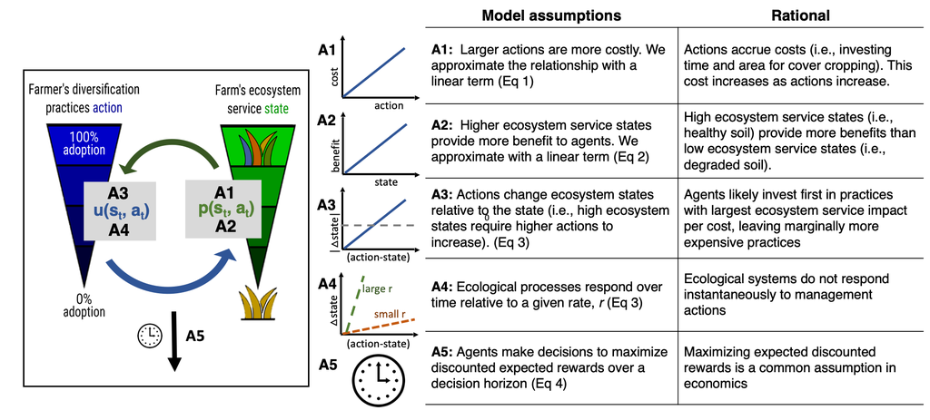

# Results

## Bistability in ecosystem services

[figure not shown]

## Importance of temporal dynamics in coupled system trajectories

Our baseline model shows how a simple coupling of human choices and ecological response can result in bistable landscapes of high and low diversification practice adoption and, as a result, high and low levels of ecosystem services (Fig 2). By vary the time horizon of the decision process, the rate of the ecological response, and the cost/benefit ratio, we find that this tipping point disappears when the speed of response of either the ecological system or decision-making process overwhelms the coupling (a proxy for decoupling). Figure 5A shows that with temporal human/environment interactions, there exists a region of cost/benefit ratio within which various bimodal ecosystem state distributions exist. However, when ecological processes become fast enough that the ecosystem responds almost immediately to farmer actions ($r=0.95$), alternate stable states do not emerge, regardless of cost-benefit ratios (Fig 5C). Similarly, as decisions become temporally myopic (in this case, with a time horizon of 2 decision cycles), the potential for bistability in adoption trajectories disappears (Fig 5B). Only when both a gradually changing environment and a forward-looking decision-maker (i.e. a farmer who takes into account potential benefits over the long term) are coupled, do tipping point phenomena emerge in the decision strategy, leading to two stable ecosystem service states (Fig 5).

[figure not shown]

## Implications for agricultural incentive design and land tenure policy

We solve the MDP on a constrained time horizon (20-decision cycles, in comparison to an infinite time horizon in Fig 2), representing the shorter horizon on which tenant farmers often make decisions (Fig 3B). Comparing the final state distribution of the long-tenure (baseline) versus the short-tenure model shows that, as a farmer’s expected land tenure duration decreases, it becomes optimal to reduce diversification adoption across a wider range of ecosystem states. This results in ecosystem state degradation even among farm sites with an initially high ecosystem service value, with 94% of farmers ending up in the simplified state at $t=20$.

While land tenure impacts the temporal horizon of land-use decisions, incentives that influence management practices are also important factors in decision-making processes and have become an integral part of farming over the past half-century (Batáry et al. 2015; Graddy-Lovelace and Diamond 2017). We explore the impact of incentive duration on the efficacy of policies to promote adoption of diversification practices by implementing two competing publicly funded incentive schemes: a short-term (two-time step) incentive which fully covers the cost of adoption, versus a longer-term (ten-time step) incentive which only partially offsets the adoption costs over those time steps. Formally, the cost of each incentive package is equal. Within the model, agents adapt their optimal decision strategy for the given cost-benefit ratio during the incentive period, and at its conclusion they revert to the baseline strategy (i.e. without payments).

We find longer, more sustained incentive programs to be more effective at encouraging adoption behavior over the critical threshold toward diversified farming (Fig 4). Once a farmer has crossed the viable ecosystem state threshold, it becomes less likely that they will return to simplified systems, even after incentives are removed. Because it takes a series of investment actions for the ecosystem service state to cross the investment threshold, longer-term incentives ultimately result in more diversification practice adoption.

[figure not shown]

[figure not shown]

# Discussion

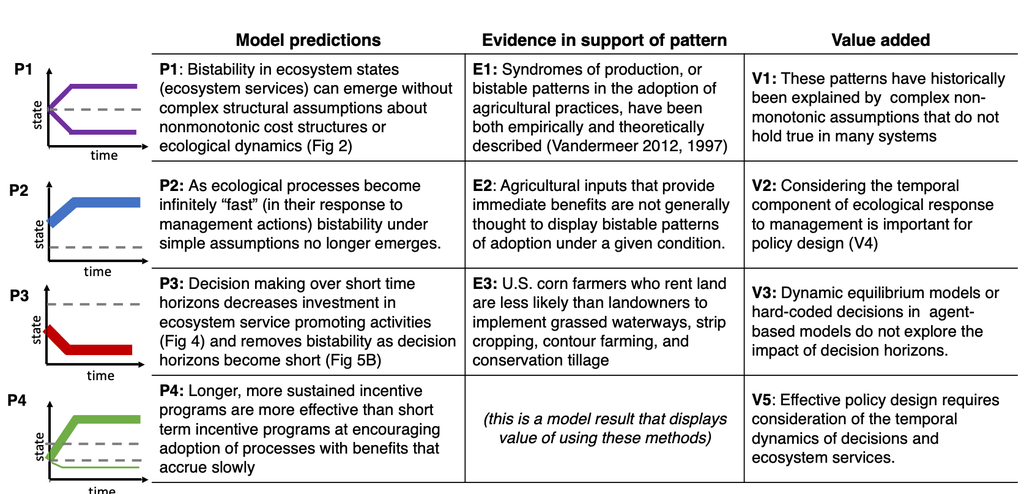

Our analysis suggests a mechanism for bistability in social-ecological systems that is the result of temporal interactions between forward-looking decisions and ecological processes rather than complex structural assumptions about either system alone. While alternate stable states within coupled human and natural systems, and farming systems in particular, have been previously explored and observed (Horan et al. 2011; Vandermeer 1997; Vandermeer and Perfecto 2012), our results shed light specifically on temporal feedbacks that likely contribute to this pattern. We show how this mechanism provides novel insights not only for social-ecological research (Fig 5), but also for agricultural policy (Fig 3 and Fig 4).

Policies designed to promote agricultural sustainability in response to stressors such as climate change or soil degradation can have unintended consequences because when designed without explicit consideration of the feedback between human decision-making and ecosystem states. Our results suggest that long-term, sustained incentives, even when only partially covering the cost of adoption, may be more effective in shifting farmers from simplified ecological states to diversified states than more concentrated short-term incentives. We show that the cost of interventions and the social-environmental benefit of those interventions are not necessarily equivalent. Rather, perceived stability of incentive programs over time may be an important driver of adoption, which can be overlooked if the temporal rates of coupled dynamics in social-environmental systems are not considered. This is particularly relevant to government payment programs and suggests that payments can be highly effective in encouraging adoption of diversification practices when implemented over long time horizons. While the possibility of a policy discontinuation may contribute to the lack of impact for short-term incentives, reduced transaction costs that come with farmers making a longer-term commitment may also partially explain the greater impact of sustained incentives as compared to concentrated incentives.

In addition to incentive policies, our analysis shows how secure land tenure can impact decision strategies and consequently is integral to increasing the adoption of diversified farming practices. This finding complements sociological research documenting how security and length of land tenure affects adoption of sustainable agricultural practices (Fraser 2004; Long et al. 2017; Richardson Jr 2015; Soule, Tegene, and Wiebe 2000). Policies that increase land tenure duration, such as regulating lease agreement terms, providing low interest loans, or promoting stable farm succession plans, may represent a key lever to enable farmers to adopt more diversified agroecological practices.

By conceptualizing the adoption of diversified farming practices through this lens, we offer new insights into important agricultural policy conundrums such as precarious land tenure and unstable incentive programs. We present a flexible model framework that can be built on to address numerous questions in social-ecological systems and agricultural policy. Expanding the boundaries of the model to include the effect of other structural factors, such as agricultural regulations, could expand the scope of questions explored.

## Mathematical description

The farmer’s decision model can be expressed as

$$\max_{\lbrace a_t \rbrace} \mathbb{E} \left[ \sum_t^T u(s_t, a_t) \gamma^t \right]$$

where $\lbrace a_t \rbrace$ is the set of available actions, $\mathbb{E}$ the expected utility operator, $u(s_t, a_t)$ the utility which the farmer associates with being in state $s_t$ and taking action $a_t$ at time $t$, $\gamma$ the myopic discount factor, and $T$ the land tenure of the farm ($T \to \infty$ if the farmer owns the land or has a long lease).

We assume a simple model of the farmer’s perceived utility $u(s_t, a_t)$ as a function of the difference between the cost $c_a$ associated with diversification practice action $a_t$, versus expected benefits $b_s$ derived from ecosystem state $s_t$, at time $t$, such that

$$u(s_t, a_t) = b_s s_t - c_a a_t$$

The ecosystem state is also dynamic, evolving according to the transition probability function $p(s_t, a_t)$, such that

$$s_{t+1} = p(s_t, a_t) := s_t + r \left(a_t - s_t \right) + \epsilon$$

where $\epsilon \sim N(0, \sigma)$. This provides a minimal state transition model in which the parameter $r$ sets the natural timescale at which the ecosystem can respond to changes in land mangement decisions, and $\sigma$ defines the width of the state transition probability distribution, capturing the noise inherent to ecological system change. While we have assumed very basic transition and utility functions for this stylized model, in general more complicated nonlinear functions for both the ecosystem state transition and perceived utility are possible using this framework.

## Model implementation

The model was developed in the *R* programming language (R Core Team 2019). The *MDPtoolbox* library was used to set up and solve the MDP (Chades et al. 2017), *tidyverse* for data analysis (Wickham et al. 2019), and *ggplot2* to generate all figures (Wickham 2016). Code for our model and the experiments conducted in this paper is available freely at https://github.com/boettiger-lab/dfs-mdp.

# References

Chades, Iadine, Guillaume Chapron, Marie-Josee Cros, Frederick Garcia, and Regis Sabbadin. 2017. *MDPtoolbox: Markov Decision Processes Toolbox*. https://CRAN.R-project.org/package=MDPtoolbox.

R Core Team. 2019. *R: A Language and Environment for Statistical Computing*. Vienna, Austria: R Foundation for Statistical Computing. https://www.R-project.org/.

Wickham, Hadley. 2016. *Ggplot2: Elegant Graphics for Data Analysis*. Springer-Verlag New York. https://ggplot2.tidyverse.org.

Wickham, Hadley, Mara Averick, Jennifer Bryan, Winston Chang, Lucy D’Agostino McGowan, Romain François, Garrett Grolemund, et al. 2019. “Welcome to the tidyverse.” *Journal of Open Source Software* 4 (43): 1686. https://doi.org/10.21105/joss.01686.